# Coursework Report

*N* removed NAs: 3

*N* removed typo: 1

*N* removed <18: 19

*N* total clean: 128

| Group | *N* | *M*<sub>age</sub> | *M*<sub>rating</sub> |
| --- | --- | --- | --- |
| Control | 64 | 20.80 | 5.80 |
| Experim | 64 | 20.94 | 6.64 |

**Main analysis results**

*t*(126) = -6.9, *p* < .001

[interactive chart not shown]

[figure not shown]

[interactive chart not shown]

# Coursework Report

Analysing Data, Spring 2020

# Methods

## Participants

```
## # A tibble: 2 x 4
##   group            n mean_age sd_age
##   <fct>        <int>    <dbl>  <dbl>
## 1 control         64     20.8   2.00
## 2 experimental    64     20.9   2.03
```

## Design

The aim of this research is to study the effect of the colour red on the ratings of attractiveness of men to women. It’s hypothesized that the colour red increases the view of the man’s status, and therefore increases his attractiveness to women. The participants viewed one of the two possible variables; a black-and-white photo of a Caucasian man selected from a standard set of photos (Corneille, Monin & Pleyers, 2005), placed on either a white (control condition) or red (experimental condition) background. The parameters for the red background were LCh(49.6, 58.8, 30.4). Both variables were factors in the experiment, that would affect the ratings given to the men. The ratings given were then based on three 9-point scales ranging from 1 (not attractive at all) to 9 (extremely attractive), for example. The three scales used were “How attractive do you think this person is?”, “How pleasant is this person to look at?”, and “If I saw this man in person, how attractive would I find him?”. Both variables will be interpreted in the same way using the same three questions, therefore a rating of 1 will be low and 9 will be high for both.

The perceived ratings of attractiveness will be higher for photos of men on a red background than for those on a white background, a t-test will be used to analyse this.

# Results

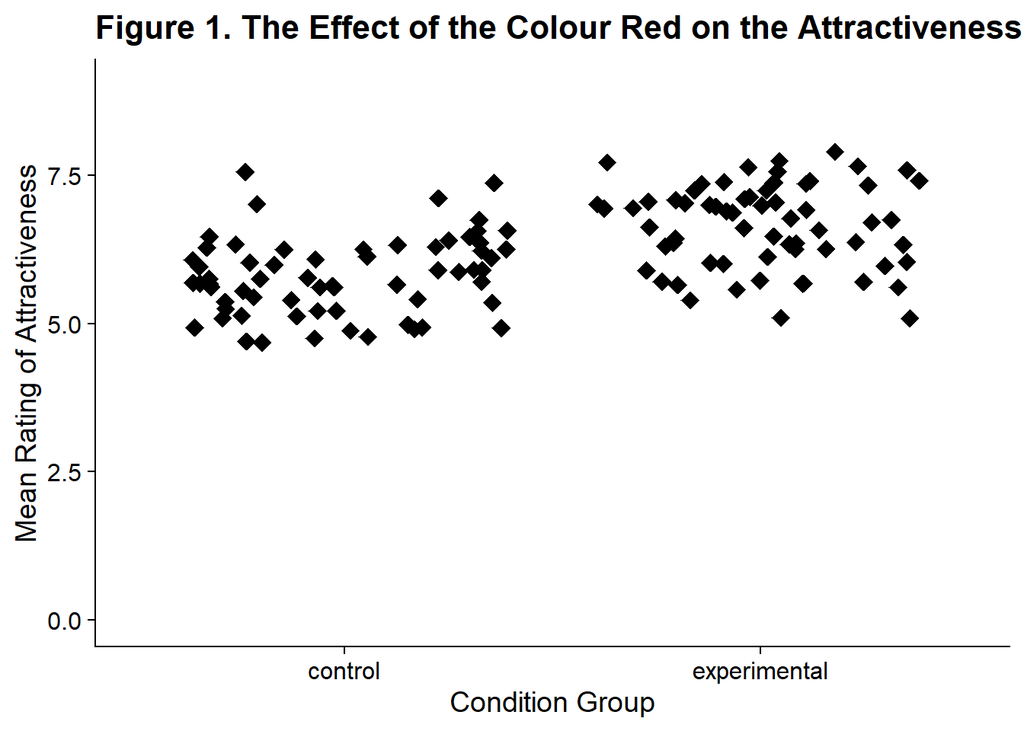

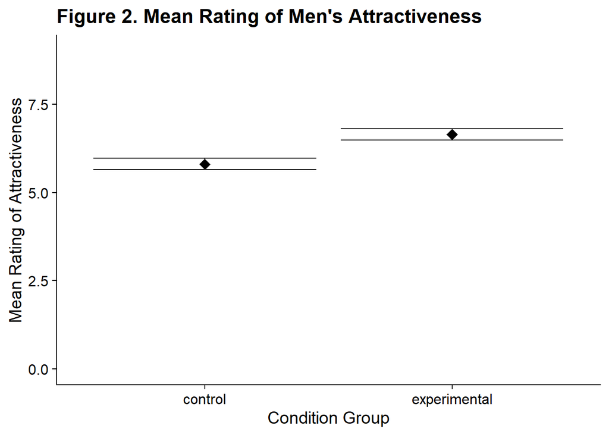

# Discussion

To summarise, the findings from this study are very similar to the findings from Elliot et al.’s original study (Elliot et al., 2010), to the extent where the means from the condition groups in both studies almost completely replicate. TThese findings are also similar to research by Sorokowski et al., who also found an increase in the average ratings from participants in red condition groups (Sorokowski et al., 2014).

Due to the similarity between this study and ones completed previously, one of the biggest strengths of this study is it’s apparent replicability. The results appear to be fairly repetitive, so it’s arguable that this is a strength not only of this specific research, but also of the research area as a general topic; it proves the effects of the colour red on attractiveness are real and there is much room for research in this area. The primary limitations of this study, however, lie in the lack of variation among the participants. The participants were all young and female, it would be of use to study further populations in order to increase the population validity of the study. It could be argued that because the women were all around the same age, the ratings of attractiveness could have been affected by extraneous variables such as age, rather than the coloured background. As a result, this demographic limits the research to only being applicable to young women, where it has the potential to apply to older women and even men. Therefore it would be beneficial to broaden the participant demographic in order to falsify this and improve population validity.

Consequently, due to the fact that this study almost replicated the original study in terms of findings, and also produced similar results to studies researching the same topic, it shows that there is scope for extra research in this area, as well as branching into other areas, such as various populations. It provides the insight that there are factors here that can affect the target variables, and warrant further investigation. For example there has been plentiful research completed into the animal world and how red can affect attractiveness in animals, through their colourings for example (Waitt et al., 2003, Donkin, 1977), as well as research into the attractiveness of men in conjunction with the colour red in humans, such as the original study in this research (Elliot et al., 2010), however I think it would be worthy of investigation into the more primitive reasons into the affect of red on attractiveness in humans; whether red is associated with higher power, wealth or physical ability, and how this factor then affects attractiveness. A further area of potential research would be into the area of other colours, not just red. Research by Sorokowski et al. (2014), briefly studied this and therefore I think it would be worthy of further investigation, for example into how certain colours can be off-putting to women and decrease ratings of attractiveness rather than increasing them, or if it’s only the colour red that increases attractiveness or whether there is potential for other colours to have a similar effect. Additionally, there has been previous research providing insight into the colour red in relation to consumer behaviour (Neal et al., 2006), and found that the colour red can be linked to increased consumerism of certain products. In our current society, dating primarily occurs online through dating apps, therefore I believe that there is scope for further investigation into the colours used by dating apps and the link to increased attractiveness of the men on the app. There could potentially a link between the colour of the background of the profiles on the app or the colour theme of the app as a whole and the amount of ‘matches’ made between people on the app, using the colour red as the experimental colour in the investigation. This research would not only be interesting from a scientific standpoint, but it would alsp potentially be beneficial for the creators of such dating apps to know, as it could increase their marketing success. This research could have plentiful positive implications.

In conclusion, the principle findings from this study are that there are clear effects from the colour red on the ratings of attractiveness given to men, however there is also a vast scope for further research to both provide supplementary support for the current studies, and to develop the research into further areas and study these effects on other populations and via alternative platforms. Overall, additional research into this topic can be extremely beneficial to many recipients, and provides a platform for much further investigation.

# References

Corneille, O., Monin, B., & Pleyers, G. (2005). Is positivity a cue or a response option? Warm glow vs. evaluative matching in the familiarity for attractive and not-so-attractive faces. Journal of Experimental Social Psychology, 41, 431–437.

Donkin, R. A. (1977). Spanish Red: An Ethnogeographical Study of Cochineal and the Opuntia Cactus.

Elliot, A. J., Kayser, D. N., Greitemeyer, T., Lichtenfeld, S., Gramzow, R. H., Maier, M. A., & Liu, H. (2010). Red, rank, and romance in women viewing men. Journal of Experimental Psychology. General, 139(3), 399–417.

Neal, C., Neal, Quester, P. G., & Hawkins, D. I. (2006). Consumer Behaviour: Implications for Marketing Strategy. McGraw-Hill Higher Education.

Sorokowski, P., Sorokowska, A., & Witzel, C. (2014). Sex differences in color preferences transcend extreme differences in culture and ecology. Psychonomic Bulletin & Review, 21(5), 1195–1201.

Waitt, C., Little, A. C., Wolfensohn, S., Honess, P., Brown, A. P., Buchanan-Smith, H. M., & Perrett, D. I. (2003). Evidence from rhesus macaques suggests that male coloration plays a role in female primate mate choice. Proceedings. Biological Sciences / The Royal Society, 270 Suppl 2, S144–S146.